# presentation

## What Do We Mean When We Talk About Polarization?

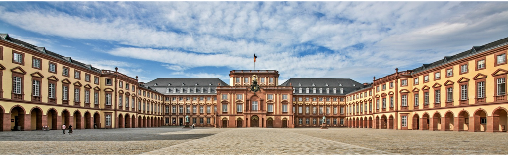

Tristan Muno – Trilateral Summer Academy 2026, uOttawa

September 8, 2026

## About me

- Born in Mainz, finished high school in 2018
- Helped logistically at an earlier version of (back then a bilateral) summer institute in 2018
- B.Ed. History & Pol. Science, M.A. Pol Science, since 2025 PhD at Uni Mannheim
- The building I actually work in:

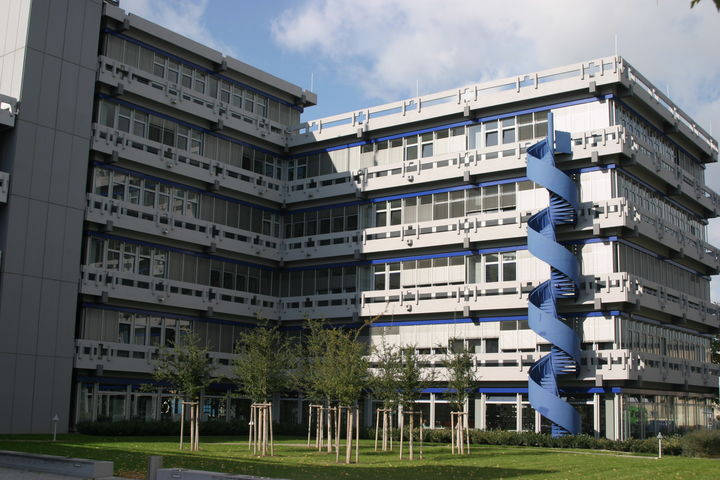

## Agenda

1. The concept – a family, not a thing
2. From political to affective polarization
3. Social identity theory
4. Measuring affective polarization
5. Affective polarization in Europe – Hahm et al. (2024)
6. Takeaways
7. Where I go from here – ongoing projects (if time)

# The Concept

## A word borrowed from physics

- Physics: polarization is the *orientation* of a wave
- Original meaning: alignment, orientation, separation
- Nothing about conflict or hostility – social science supplied that

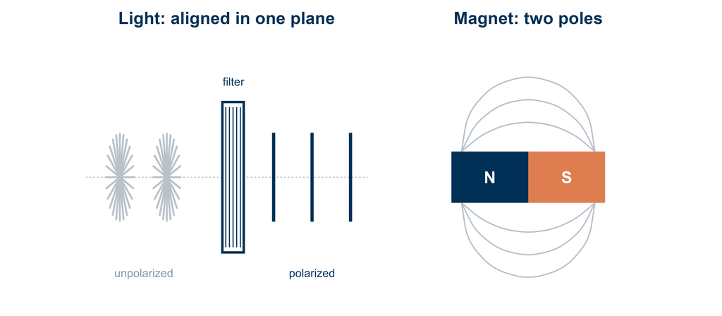

## Polarization is a family of concepts

- Broadest usage: alignment, separation, sorting, divergence
- Four mathematically distinct things share the name
- They can move in **opposite directions in the same data**

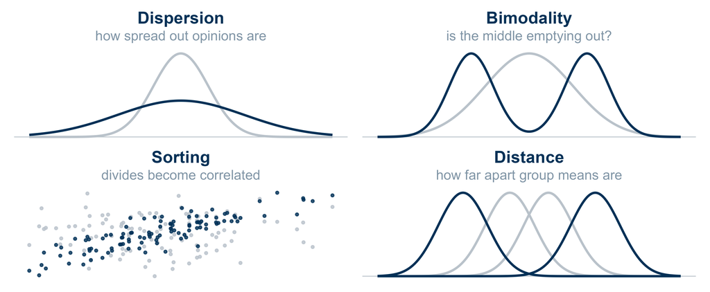

## Three further axes

- Bipolar vs multipolar – nothing requires two camps
- State vs process – a snapshot vs a trend
- Object vs target – who is polarized against whom?

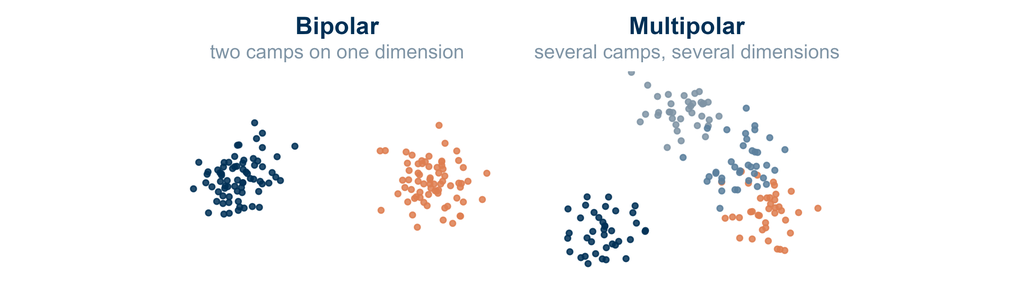

# From Political to Affective Polarization

## The debate on political polarization

- Originally *ideological*: divergence on issues or left-right
- Elite level: clear US congressional divergence since the 1970s
- Mass level: fiercely contested through the 2000s
- Fiorina et al. (2008) – better sorted, not more extreme
- Abramowitz and Saunders (2008) – genuinely polarized, especially the engaged

## *Affect, not ideology*

- Iyengar et al. (2012): ask how partisans *feel*, not where they stand
- Dislike substantially exceeds substantive disagreement
- Iyengar and Westwood (2015): partisan discrimination exceeds racial discrimination
- Two components: in-group favoritism **and** out-group animosity

> “the tendency of people identifying as [partisans] to view opposing partisans negatively and copartisans positively” (Iyengar and Westwood 2015; Iyengar et al. 2019)

# Social Identity Theory

## Why would affect exceed disagreement?

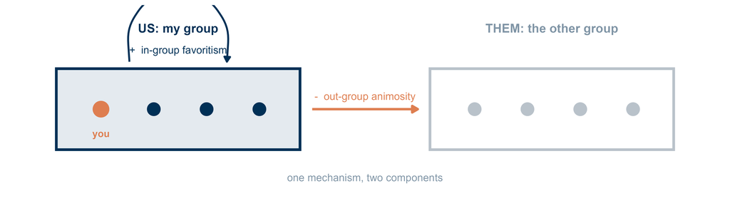

# Measuring Affective Polarization

## The workhorse

- Feeling thermometers / like-dislike scales: rate each party 0–10 (or 0–100)
- Simplest AP measure: in-group score minus out-group score

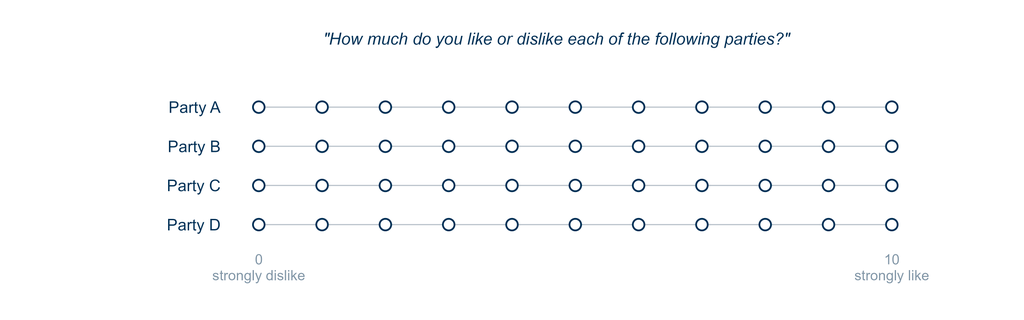

## The thermometer in action

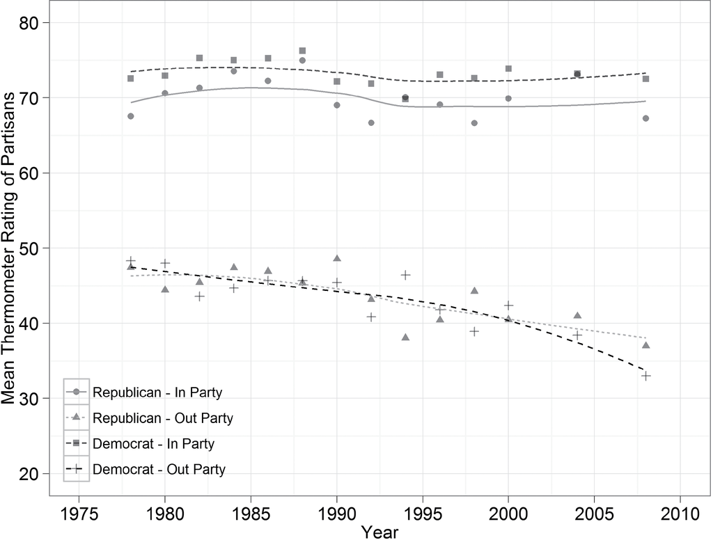

*Note:* Figure from Iyengar et al. (2012).

## API: mean distance from your party

- With many parties there is no single “the other party” to subtract
- Reiljan (2020): the **mean distance** from your party to each of the others – distances enter **unsquared**

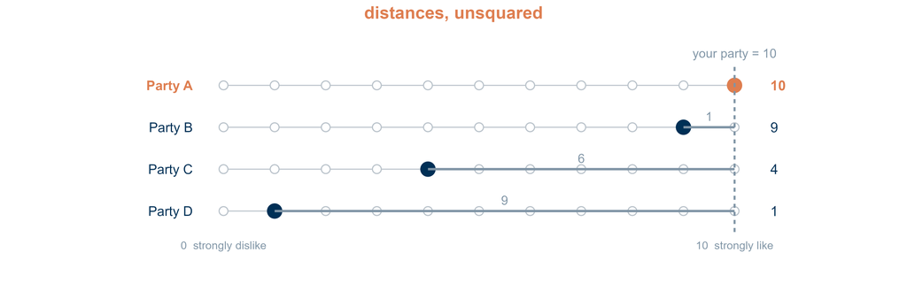

$$\text{API}_i \;=\; L_{\text{own}} - \overline{L}_{\text{others}} \;=\; 10 - \frac{9+4+1}{3} \;=\; 10 - \frac{14}{3} \;=\; \mathbf{5.33}$$

## Distance: the same distances, squared

- Wagner (2021): the **root-mean-square distance** from your most-liked party to each of the others
- Same anchor, same three parties as API – the only difference is **squaring**

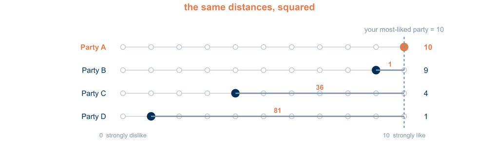

$$\text{Distance}_i \;=\; \sqrt{\frac{1+36+81}{3}} \;=\; \sqrt{\frac{118}{3}} \;=\; \mathbf{6.27}$$

## Spread: no anchor at all

- Wagner (2021): the **sample standard deviation** of your ratings – deviations from your own mean, squared, over $n-1$
- No in-group required – the only one of the three computable for a non-partisan
- Same four ratings: API **5.33** · Distance **6.27** · Spread **4.24**

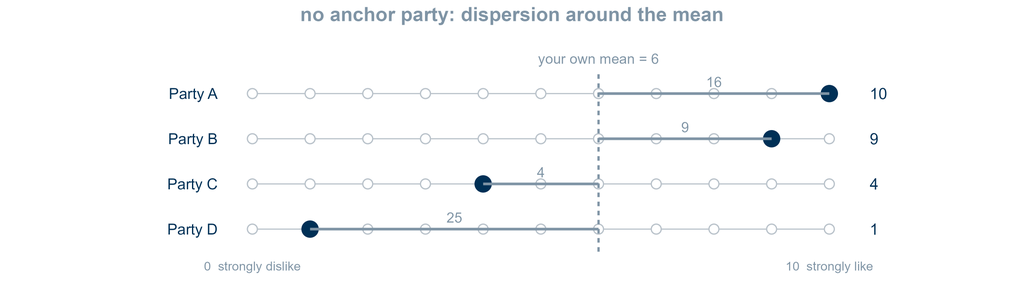

$$\text{Spread}_i \;=\; \sqrt{\frac{16+9+4+25}{3}} \;=\; \sqrt{18} \;=\; \mathbf{4.24}$$

## Two critiques that matter

- **What is “affect”?** Like/dislike blends emotion with cognitive and instrumental evaluation
- It collapses anger, fear, disgust and contempt – emotions with opposite behavioral implications (Bakker and Lelkes 2024)
- **Which target?** Asked about a party, respondents picture elites and activists – not the neighbour who rarely discusses politics (Druckman and Levendusky 2019)
- Name the *ordinary* partisan and estimated hostility drops sharply
- So: much measured “mass animosity” may be **elite animosity wearing a costume**

## Two dimensions, four different questions

Target (Areal and Harteveld 2024; Reiljan et al. 2024) crossed with measurement mode – the literature crowds into one cell

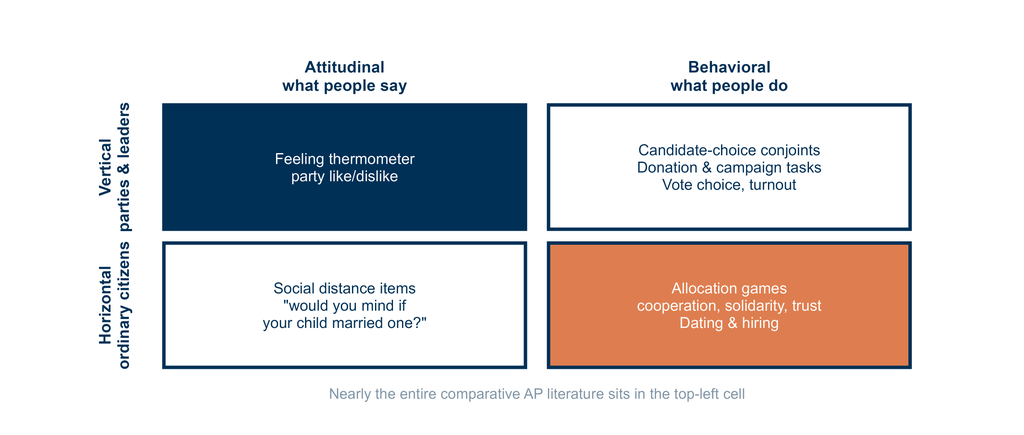

# Affective Polarization in Europe

## Data

- Hahm et al. (2024): cross-national conjoint experiment
- All 25 EU member states, ~29,800 respondents, fielded May–August 2019
- ~1,200 per country, broadly representative on age and gender
- Respondents play incentivized-format allocation games
- Rare combination: comparative scope **and** behavioral outcomes

## Design

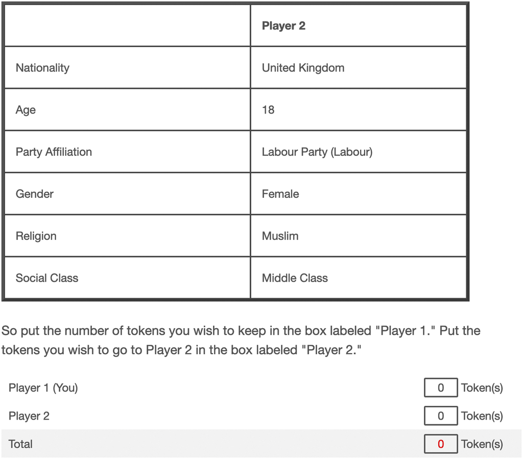

*Note:* Figure from Hahm et al. (2024), Figure 1.

## Why this beats a thermometer

- Explicitly **horizontal**: the co-player is an ordinary co-national
- Explicitly **behavioral**: tokens, not a self-reported feeling
- A **non-partisan baseline** condition – party simply not shown
- So in-group favoritism and out-group derogation are estimated *separately*
- Conjoints reduce social desirability bias (Horiuchi et al. 2022), and randomization identifies causal effects (Hainmueller et al. 2014)

## Partisanship dominates every other divide

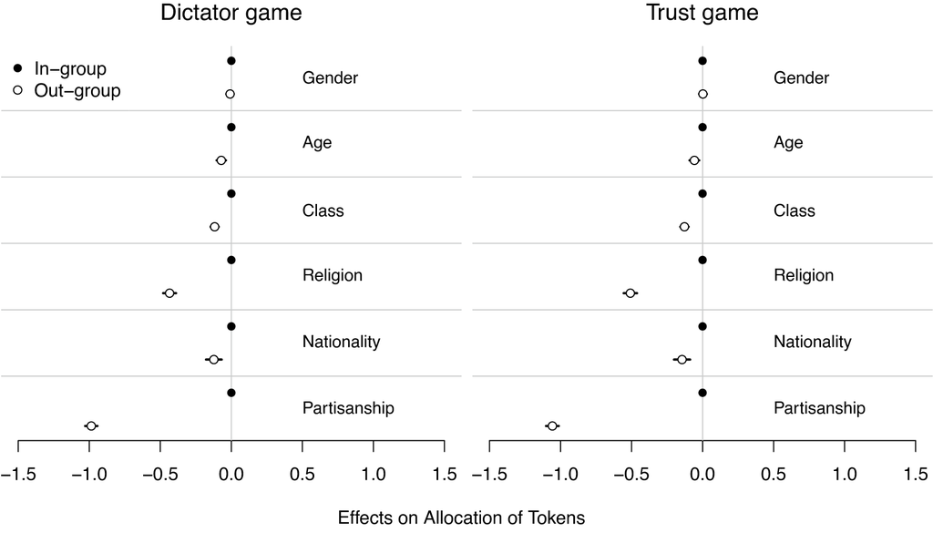

*Note:* Figure from Hahm et al. (2024), Figure 2. Pooled, J = 29,827, N = 178,936.

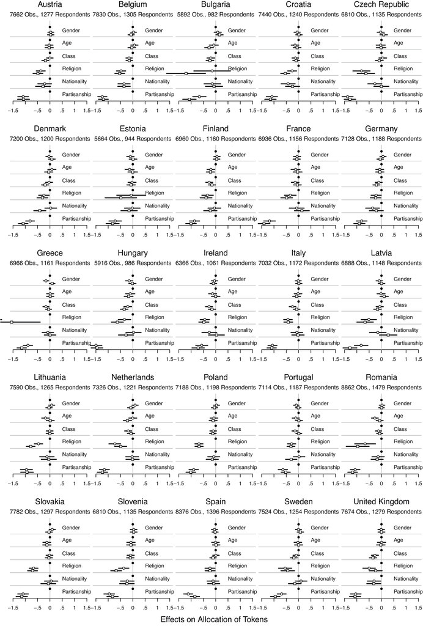

*Note:* Figure from Hahm et al. (2024), Figure 3. Dots = dictator game, squares = trust game.

## In-group favoritism vs out-group derogation

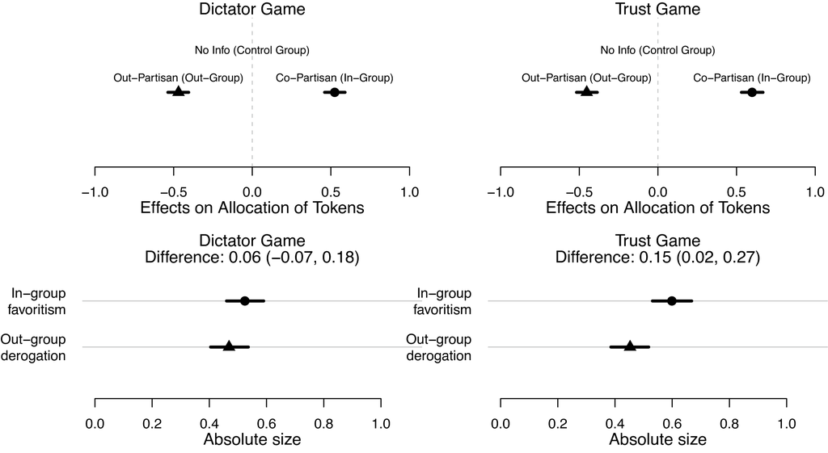

*Note:* Figure from Hahm et al. (2024), Figure 4. Partisan identifiers only. J = 18,925, N = 77,456.

## The decomposition, country by country

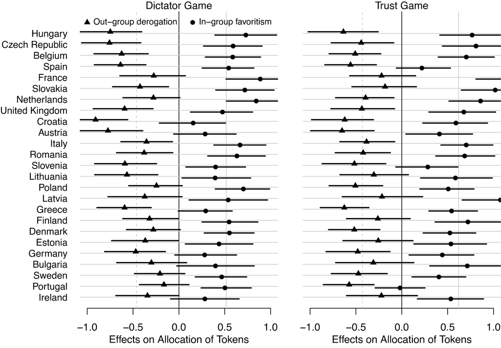

*Note:* Figure from Hahm et al. (2024), Figure 5. Circles = in-group favoritism, triangles = out-group derogation.

## Why the variation? Coalitions

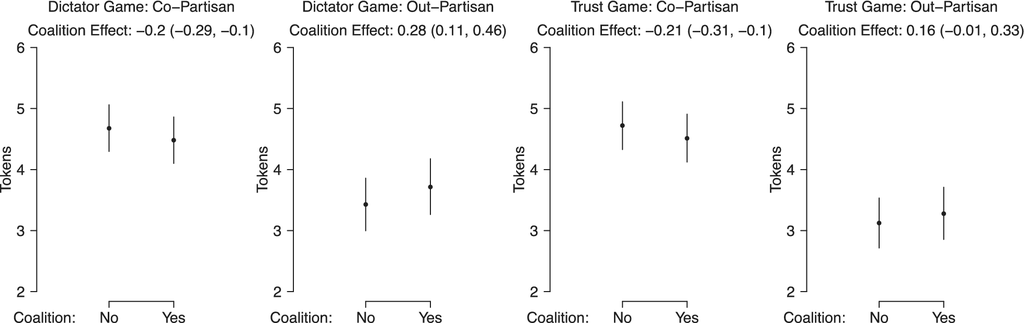

*Currently in coalition* – Hahm et al. (2024), Figure 6

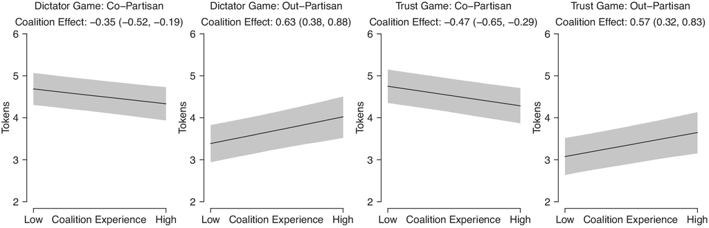

*Years of coalition experience* – Hahm et al. (2024), Figure 7

## A snapshot, not a trend

- Fielded **2019** – pre-COVID, pre-Ukraine, pre-inflation, pre much of the current radical-right wave
- A **state**, not a process – one measurement, no time series
- And one cell of the grid: **horizontal** (an ordinary co-national, not a party or a leader) and **behavioral**
- How any of this has moved since 2019 is a separate, open question

# Takeaways

## Is it bad for democracy? Depends which one you mean

- The concern: less compromise, lower institutional confidence (Finkel et al. 2020)
- The pushback: reducing animosity does **not** move democratic attitudes (Broockman et al. 2023)
- The guardrail case: hostility to anti-democratic parties may be healthy (Harteveld et al. 2022)
- Agonistic vs antagonistic – adversary or enemy (Mouffe 2013)
- **One thermometer number cannot tell any of these apart**

## Five things to take with you

- Polarization is a family of concepts, not a thing
- Measurement choices are theoretical choices
- Target **and** mode both matter – vertical/horizontal $\times$ attitudinal/behavioral give different answers about the same people
- In Europe, in-group favoritism is at least as large as out-group derogation – the US out-group-animus story does not simply travel
- Whether AP is “bad for democracy” depends on which AP you mean

# Where I Go From Here

## Who counts as a partisan…

- AP is measured **on partisans** – someone must decide who counts
- The usual filter: “do you feel close to a party?”
- Yes-shares run from ~40% to over 80% across member states
- So the choice moves the **population of inference** – unevenly

## …and how does this influence AP estimates?

- Hold the vote anchor constant, vary only whether attachment is **reported**
- **Attitudinal:** self-identified partisans sit higher on all three thermometer measures
- **Behavioral:** both types withhold roughly 0.7–1.0 tokens from an out-partisan
- **Preliminary** – pooled cross-national descriptives, not yet the within-party test

## Partisan sorting and the Muslim penalty

- The conjoint randomizes religion **and** partisanship independently – the interaction is directly estimable
- **Preliminary:** a Muslim cue costs a *co-partisan* more (–0.67 tokens) than an *out-partisan* (–0.41)
- So the partisan gap **narrows**: 1.08 tokens for Christian targets, 0.81 for Muslim ones
- **Planned:** reweight to the joint distribution of party $\times$ religion that actually exists, then test for floor effects

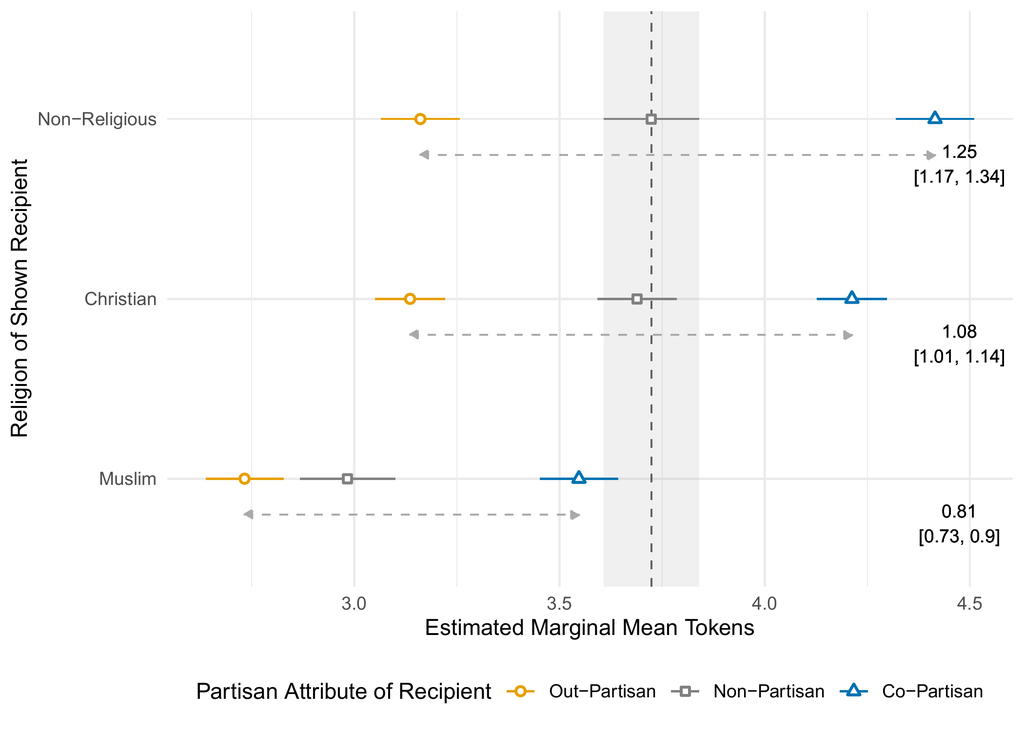

Estimated marginal means with 95% CIs, trust game. *Preliminary.*

## Historical Muslim rule and anti-Muslim bias

- Respondents are **geocoded** – linkable to regions once under Muslim rule
- Question: is behavioral anti-Muslim bias *attenuated* where contact ran for centuries?
- Treatment as a **probabilistic surface**, not a crisp polygon – source uncertainty carried into the estimate
- **Planned, no estimates yet** – the map shows the variation and coverage the design rests on

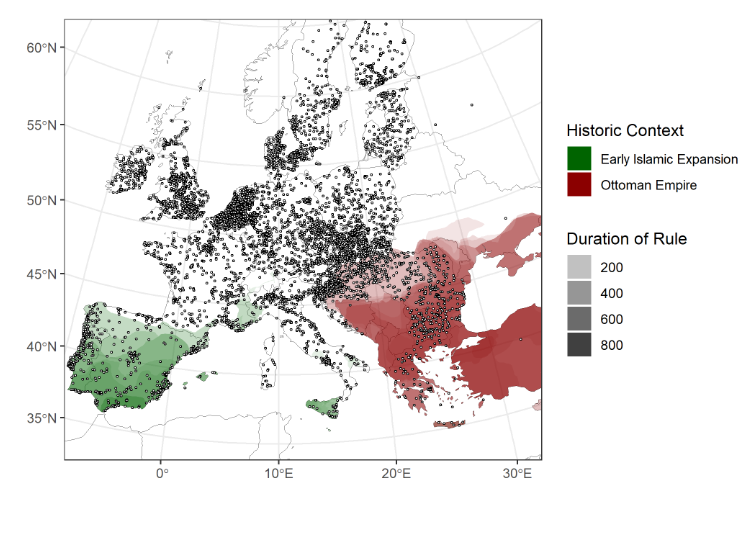

Historical extent and duration of Muslim rule. Black points are georeferenced respondents. *Planned project – no estimates yet.*

# Thank you for your attention!

I warmly welcome any feedback, ideas, or critical thoughts ❤

## References

Abramowitz, Alan I., and Kyle L. Saunders. 2008. “Is Polarization a Myth?” *The Journal of Politics* 70 (2): 542–55. https://doi.org/10.1017/S0022381608080493.

Abramowitz, Alan I., and Steven W. Webster. 2018. “Negative Partisanship: Why Americans Dislike Parties but Behave Like Rabid Partisans.” *Political Psychology* 39: 119–35. https://doi.org/10.1111/pops.12479.

Areal, João, and E. Harteveld. 2024. “Vertical Vs Horizontal Affective Polarization: Disentangling Feelings Towards Elites and Voters.” *Electoral Studies* 90. https://doi.org/10.1016/j.electstud.2024.102814.

Bakker, Bert N., and Yphtach Lelkes. 2024. “Putting the Affect into Affective Polarisation.” *Cognition and Emotion* 38 (4): 418–36. https://doi.org/10.1080/02699931.2024.2362366.

Brewer, Marilynn B. 1999. “The Psychology of Prejudice: Ingroup Love and Outgroup Hate?” *Journal of Social Issues* 55 (3): 429–44. https://doi.org/10.1111/0022-4537.00126.

Broockman, David E., Joshua L. Kalla, and Sean J. Westwood. 2023. “Does Affective Polarization Undermine Democratic Norms or Accountability? Maybe Not.” *American Journal of Political Science* 67 (3): 1–21. https://doi.org/10.1111/ajps.12719.

Druckman, James, and Matthew Levendusky. 2019. “What Do We Measure When We Measure Affective Polarization?” *Public Opinion Quarterly* 83 (1): 114–22. https://doi.org/10.1093/poq/nfz003.

Finkel, Eli J., Christopher A. Bail, Mina Cikara, et al. 2020. “Political Sectarianism in America.” *Science* 370 (6516): 533–36. https://doi.org/10.1126/science.abe1715.

Fiorina, Morris P., Samuel A. Abrams, and Jeremy C. Pope. 2008. “Polarization in the American Public: Misconceptions and Misreadings.” *The Journal of Politics* 70 (2): 556–60. https://doi.org/10.1017/S002238160808050X.

Hahm, Hyeonho, David Hilpert, and Thomas König. 2024. “Divided We Unite: The Nature of Partyism and the Role of Coalition Partnership in Europe.” *American Political Science Review* 118 (1): 69–87. https://doi.org/10.1017/S0003055423000266.

Hainmueller, Jens, Daniel J. Hopkins, and Teppei Yamamoto. 2014. “Causal Inference in Conjoint Analysis: Understanding Multidimensional Choices via Stated Preference Experiments.” *Political Analysis* 22 (1): 1–30. https://doi.org/10.1093/pan/mpt024.

Harteveld, Eelco, Philipp Mendoza, and Matthijs Rooduijn. 2022. “Affective Polarization and the Populist Radical Right: Creating the Hating?” *Government and Opposition* 57 (4): 703–27. https://doi.org/10.1017/gov.2021.31.

Horiuchi, Yusaku, Zachary Markovich, and Teppei Yamamoto. 2022. “Does Conjoint Analysis Mitigate Social Desirability Bias?” *Political Analysis* 30 (4): 535–49. https://doi.org/10.1017/pan.2021.30.

Huddy, Leonie, Lilliana Mason, and Lene Aarøe. 2015. “Expressive Partisanship: Campaign Involvement, Political Emotion, and Partisan Identity.” *American Political Science Review* 109 (1): 1–17. https://doi.org/10.1017/S0003055414000604.

Iyengar, Shanto, Yphtach Lelkes, Matthew Levendusky, Neil Malhotra, and Sean J. Westwood. 2019. “The Origins and Consequences of Affective Polarization in the United States.” *Annual Review of Political Science* 22 (1): 129–46. https://doi.org/10.1146/annurev-polisci-051117-073034.

Iyengar, Shanto, Gaurav Sood, and Yphtach Lelkes. 2012. “Affect, Not Ideology: A Social Identity Perspective on Polarization.” *Public Opinion Quarterly* 76 (3): 405–31. https://doi.org/10.1093/poq/nfs038.

Iyengar, Shanto, and Sean J Westwood. 2015. “Fear and Loathing Across Party Lines: New Evidence on Group Polarization.” *American Journal of Political Science* 59 (3): 690–707. https://doi.org/10.1111/ajps.12152.

Mouffe, Chantal. 2013. *Agonistics: Thinking the World Politically*. Verso Books.

Reiljan, Andres. 2020. “‘Fear and Loathing Across Party Lines’(also) in Europe: Affective Polarisation in European Party Systems.” *European Journal of Political Research* 59 (2): 376–96. https://doi.org/10.1111/1475-6765.12351.

Reiljan, Andres, Diego Garzia, Frederico Ferreira Da Silva, and Alexander H Trechsel. 2024. “Patterns of Affective Polarization Toward Parties and Leaders Across the Democratic World.” *American Political Science Review* 118 (2): 654–70. https://doi.org/10.1017/S0003055423000485.

Roccas, Sonia, and Marilynn B. Brewer. 2002. “Social Identity Complexity.” *Personality and Social Psychology Review* 6 (2): 88–106. https://doi.org/10.1207/S15327957PSPR0602_01.

Röllicke, Lena. 2023. “Polarisation, Identity and Affect - Conceptualising Affective Polarisation in Multi-Party Systems.” *Electoral Studies* 85. https://doi.org/10.1016/j.electstud.2023.102655.

Tajfel, Henri, Michael G. Billig, Robert P. Bundy, and Claude Flament. 1971. “Social Categorization and Intergroup Behaviour.” *European Journal of Social Psychology* 1 (2): 149–78. https://doi.org/10.1002/ejsp.2420010202.

Wagner, Markus. 2021. “Affective Polarization in Multiparty Systems.” *Electoral Studies* 69: 102199. https://doi.org/10.1016/j.electstud.2020.102199.